# Estimating the Timescale and Rate of Evolution

Speciation Genomics · PB 495/595 Plant Evolutionary Biology

George P. Tiley

22 October 2026

## Continuing from phylogenies

- We can estimate trees. Trees have branch lengths.
  1. Branch lengths are in **substitutions/site** and are the product of **rate of evolution × time**.
  2. Branch lengths in coalescent units are the product of **effective population size × time**.
- To get absolute time (e.g. millions of years) we must separate rate from time. This is done with **calibrations**.
- We can get dates and rates from trees with molecular clock models
  1. **least-squares estimation of divergence times from distances**
  2. calibration densities with Bayesian methods
  3. **relaxed clocks** can accommodate rate variation across branches.

## Learning objectives

By the end you should be able to:

- Describe how the **nonparametric bootstrap** works and interpret bootstrap support for nodes.
- Connect the **molecular clock** hypothesis to the neutral theory of molecular evolution ($\rho=\mu$).
- Estimate node heights from a distance matrix by **least squares** under a strict clock and convert them to absolute ages with a calibration.
- Explain why branch length **confounds rate and time**, and how multiple **calibrations** help us separate the two.
- Contrast **strict** and **relaxed** clocks.
- Judge how **calibration choice** and **clock model** change a dated tree, and why to compare posterior with prior.

# Statistical support: the bootstrap

## Why we need a measure of uncertainty

- Last time’s tree is a **point estimate** from one finite alignment. A different sample of sites would give a (slightly) different tree.
- **Ideal:** repeat the sequencing experiment many times, re-estimate the tree each time, and see how often a clade recurs. We can’t — we only have *one* alignment.
- **The bootstrap idea** (Efron 1979): treat the observed data as a stand-in for the population and **resample from it**. Replicate data sets mimic what new data sets would look like.
- Applied to phylogenies by Felsenstein (1985); it is now the standard measure of **clade support** in ML and distance analyses.

## The nonparametric bootstrap for an alignment

1. **Resample columns** of the alignment **with replacement** until the new alignment is as long as the original — a **pseudoreplicate**.
2. **Re-estimate** the tree (or distances, or ages) from the pseudoreplicate with the **same method**.
3. **Repeat** $B$ times (100–1000).

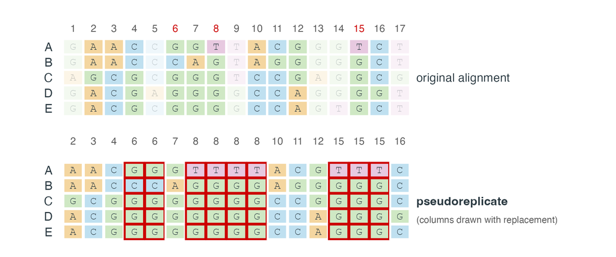

- Some columns are drawn several times, others **not at all**: on average only 63% of the original columns appear ($1-(1-1/L)^L \to 1-1/e$).
- Valid because sites are treated as **independent draws** from the same process.

## From replicates to clade support

Toy data: the 17-site A–E alignment, UPGMA tree, $B=1000$ pseudoreplicates.

- **Bootstrap support** of a clade = the **percentage of replicate trees that contain it** (Felsenstein 1985).
- Draw the values on the tree estimated from the **original** data; a **majority-rule consensus** of the replicates summarises them when topologies differ.
- (A,B) and (D,E) recur in 83–86% of replicates; (C,(D,E)) only in **53%**: 17 sites are too few to resolve it.
- More sites → more consistent replicates → higher support.

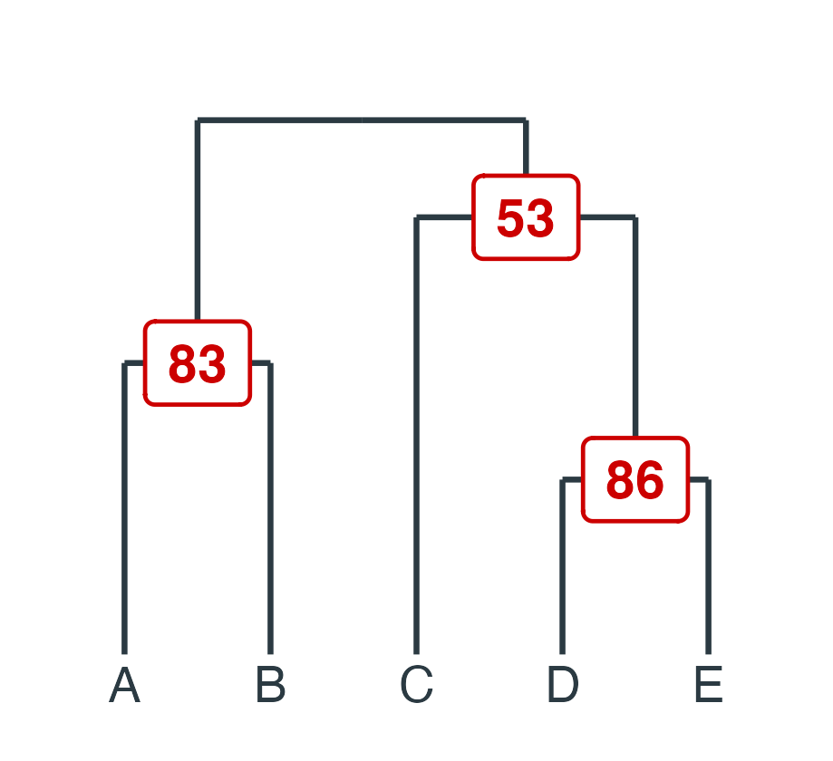

## How to read bootstrap support

**What it is**

- How **consistently the data** support a clade under resampling, *given the method and model*.
- A measure of **sampling error**: sites that conflict with the clade are common or rare.
- Rule of thumb: ≥70% is “reasonably supported”, ≥95% “strongly supported”. In simulations the bootstrap was **conservative** — 70% often corresponded to ≥95% probability that the clade is real (Hillis and Bull 1993).

**What it is not**

- **Not** the probability that the clade is true.
- Not protection from **systematic errors**. For example, a misspecified model can give **100%** support to a wrong clade.
- Not a measure of **gene-tree discordance**. Concatenation can give high support to a species tree with high ILS.

## Bootstrap variants

- **Sites are not really independent.** Linked sites in a gene share one history: for genomic data, block resampling is sometimes used.
- **Speed.** Thousands of ML bootstraps are slow. The **ultrafast bootstrap** in IQ-TREE approximates it quickly by using the tree search itself. Ultrafast bootstraps use ≥95% as the cut-off (Hoang et al. 2018).
- **Parametric bootstrap:** simulate alignments from the *fitted model and tree*, re-estimate, and compare. This can be useful for assessing model fit rather than sampling error.
- **Bootstrap vs. posterior probability:** a Bayesian posterior probability is not on the same scale and is usually **higher** than bootstrap support (forthcoming).

## Bootstrapping node ages

The same recipe gives **uncertainty on any estimate** computed from the alignment — including node ages:

1. Resample alignment columns.
2. Recompute the distance matrix, then the least-squares **node heights** (or ages, after calibration) — introduced in the least-squares section below.
3. Repeat $B$ times; the middle 95% of replicates is a **bootstrap percentile interval**.

Toy example: root height $=4.58$ substitutions, bootstrap 95% interval **3.67–5.67** — wide, as expected from 17 sites.

- Fixes the “**point estimates only**” limitation of least squares.
- Covers sampling error only, not calibration or model error.

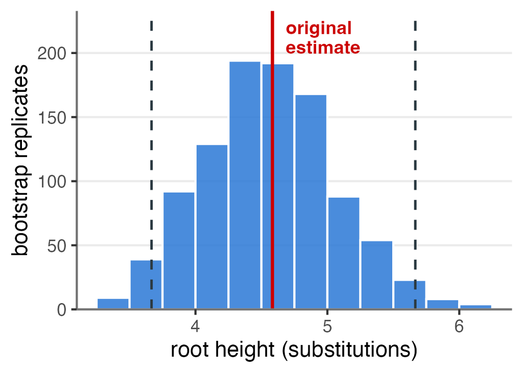

# The molecular clock

## Rate × time

A branch length in substitutions per site is

$$b = r \times t \quad(\text{rate} \times \text{time}).$$

The **molecular clock** hypothesis: $r$ is roughly constant across lineages, so branch lengths are proportional to time. This hypothesis is based in the neutral theory of molecular evolution. Recall the neutral substitution rate is the mutation rate ($\rho=\mu$), which is **independent of population size**. If $\mu$ is similar across lineages, the molecular clock should be **constant**.

# Least-squares dating

## From distances to node ages

Building off of neighbor-joining, we can use the pairwise distances to estimate node ages using least-squares.

- **Input:** a matrix of pairwise **distances** $d_{ij}$ (substitutions/site) and a **rooted tree topology**.
- **Output:** an **age for every internal node**.
- **Idea:** choose node ages so that the distances *expected* by the tree based on a linear regression are as close as possible to the distances we *observe*.

## The clock model for distances

Under a **strict clock** every lineage has the same rate $r$, so all tips are the same distance from the root (the tree is **ultrametric**). Let $m(i,j)$ be the **most recent common ancestor** (MRCA) of tips $i$ and $j$, and define its **height** $h_m = r\,t_m$ (substitutions per site since the node). Then the distance between two tips is the path up to the MRCA and back down:

$$d_{ij} \;=\; 2\,r\,t_{m(i,j)} \;=\; 2\,h_{m(i,j)}.$$

- One parameter per **internal node** ($h_m$), shared by every pair of tips that coalesce there.
- There can be many pairs for a node, and some randomness will ensure they are not equal.
- So we need a criterion for “as close as possible”.

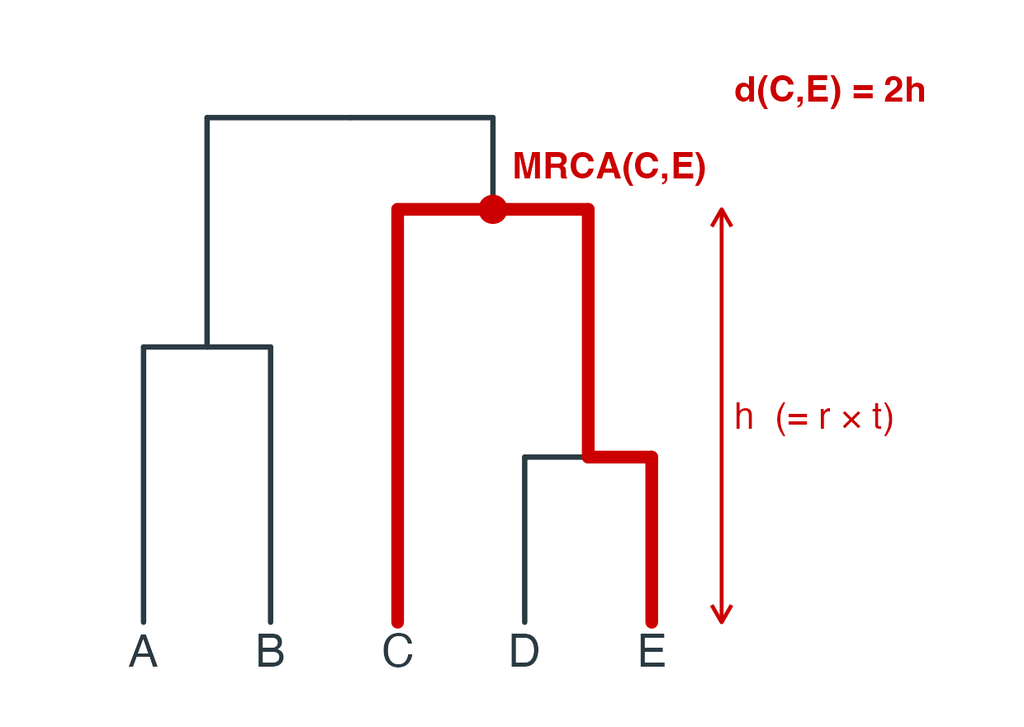

## The least-squares criterion

Choose node heights $h$ to minimise the **weighted sum of squared residuals**

$$S(h) \;=\; \sum_{i<j} w_{ij}\,\bigl(d_{ij} - 2h_{m(i,j)}\bigr)^2 .$$

With **equal weights** ($w_{ij}=1$) each node can be solved on its own: set $\partial S/\partial h_m=0$,

$$\hat h_m \;=\; \frac{1}{2}\,\overline{d}_m,
\qquad
\overline{d}_m=\text{mean of } d_{ij} \text{ over all pairs whose MRCA is } m .$$

Each node age is half the average distance across it. Ages must also satisfy the condition that a *child is younger than its parent*

## Worked example: the A–E toy matrix

Fix the topology $((A,B),(C,(D,E)))$ and group the 10 distances by their MRCA:

| Node $m$ | Pairs (distances) | $\overline{d}_m$ | $\hat h_m=\overline{d}_m/2$ |
| --- | --- | --- | --- |
| (D,E) | DE = 3 | 3 | **1.50** |
| (A,B) | AB = 5 | 5 | **2.50** |
| (C,(D,E)) | CD = 8, CE = 7 | 7.5 | **3.75** |
| root | AC = 9, AD = 9, AE = 8, BC = 10, BD = 10, BE = 9 | 9.17 | **4.58** |

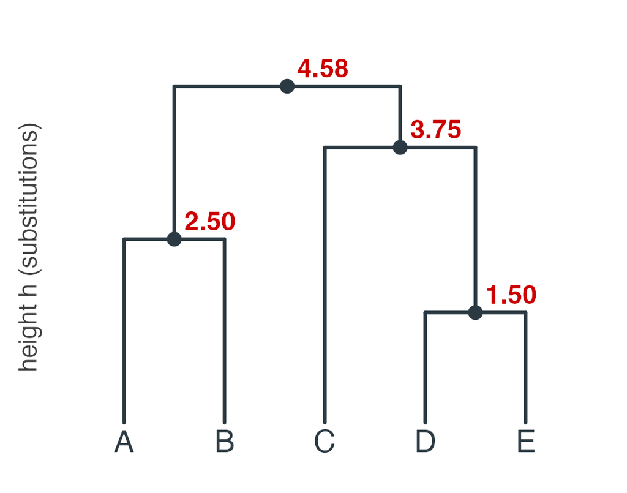

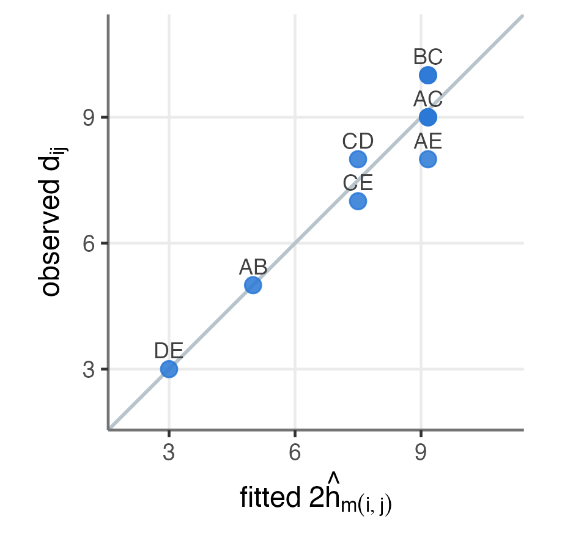

Residual sum of squares $=3.33$, almost all from the six **root** pairs ($2.83$) — the data are only *approximately* clock-like.

## Beyond a strict clock: least squares on branch lengths

Real trees are rarely ultrametric. Instead of tip-to-tip distances, use the **branch lengths** $b_i$ already estimated by ML (substitutions/site) on a rooted tree. Estimate node times $t$ and a single rate $r$ by

$$\min_{r,\,t}\;\sum_{\text{branches } i} w_i\,\Bigl(b_i - r\,\bigl(t_{\text{child}(i)} - t_{\text{parent}(i)}\bigr)\Bigr)^2
\quad\text{subject to } t_{\text{parent}}<t_{\text{child}}.$$

- Tips may have **different sampling dates**, so this also covers serially sampled data.
- The advantage of why this old approach is still used is that it is very fast. Modern work is still done (To et al. 2016) as it is scalable to thousands of tips and works for closely-related individuals.
- **Calibrations** can be used to convert node heights to absolute time.
- Rate variation among branches is not modelled.

## One calibration puts the tree on an absolute time axis

Least squares gives heights $\hat h_m$ in substitutions. Under a strict clock $h_m=r\,t_m$, so **any one node of known age** fixes the scale:

$$\hat r=\frac{\hat h_{\text{cal}}}{t_{\text{cal}}},
\qquad
\hat t_m=\frac{\hat h_m}{\hat r}=\hat h_m\times\frac{t_{\text{cal}}}{\hat h_{\text{cal}}}.$$

Example tree, root calibrated to **100 My**:

- Scale $=100/4.58 = 21.8$ My per substitution
- $\hat r = 4.58/100 = 0.046$ substitutions/My
- $\hat t$: (C,(D,E)) = **82 My**, (A,B) = **55 My**, (D,E) = **33 My**

Calibrating (C,(D,E)) to 80 My instead gives a root of 97.8 My.

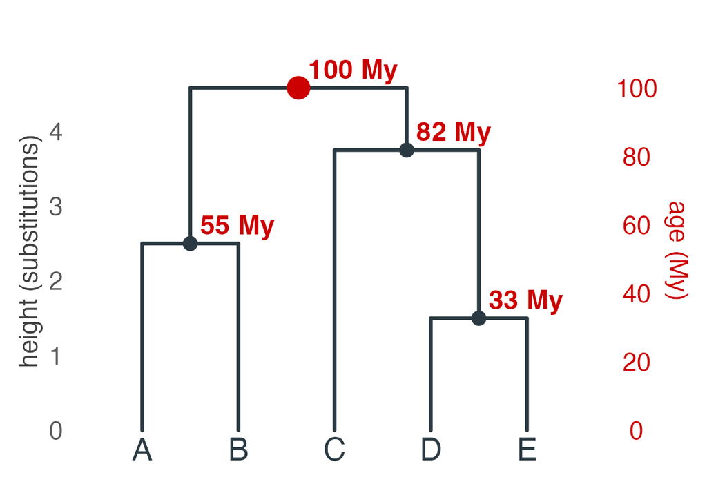

- All ages are the heights **rescaled**: ratios of node ages never change; the calibration sets only the scale.
- **Good enough?** For **closely related species over recent time scales** (similar life histories, so similar rates), a strict clock and one calibration (a recorded age of domestication or a known mutation rate) is a reasonable first estimate.
- It degrades over time due to **rate variation** (e.g. herbaceous vs. woody plants).

# Calibrations and rate variation in plants

## Rate–time non-identifiability

From sequence data we observe only the **product** $b=rt$ — as the least-squares fit showed, the data alone give heights in substitutions, and the scale is set only by external time information. Doubling the rate and halving the time gives the *identical* likelihood:

$$b = r\,t = (2r)\left(\tfrac{t}{2}\right).$$

- **Molecular data alone cannot give absolute ages.** We need **external time information** — as little as one calibration under a strict clock, but more are needed when there is rate variation.

## Calibrations make rate and time identifiable

External evidence fixes ages (or age *distributions*) at nodes/tips:

- **Fossils** — a dated fossil places a *minimum* age on a clade (often a soft prior).
- **Secondary calibrations** — ages from a previous dated study.
- **Biogeographic** — island emergence, vicariance events (e.g. Hawaiian island ages).

Calibrations are **priors on time**, layered onto the rate–time product. Their choice and placement is data driven but requires justification from organismal experts.

## Where do calibrations come from?

[figure not shown]

Crowns versus stems. Fig. 1 from Renner (2005)

## Why multiple calibrations are needed

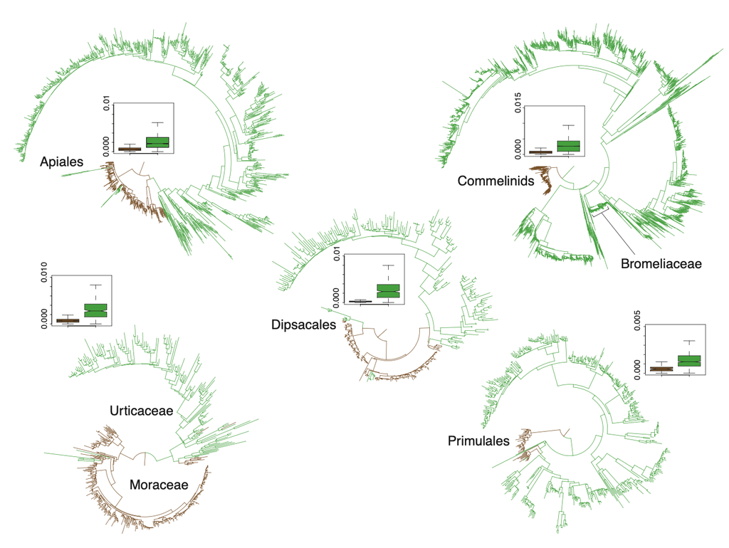

Faster rates of evolution in herbaceous plants compared to woody plants. Fig. 1 from Smith and Donoghue (2008)

## Strong effect of calibration choice

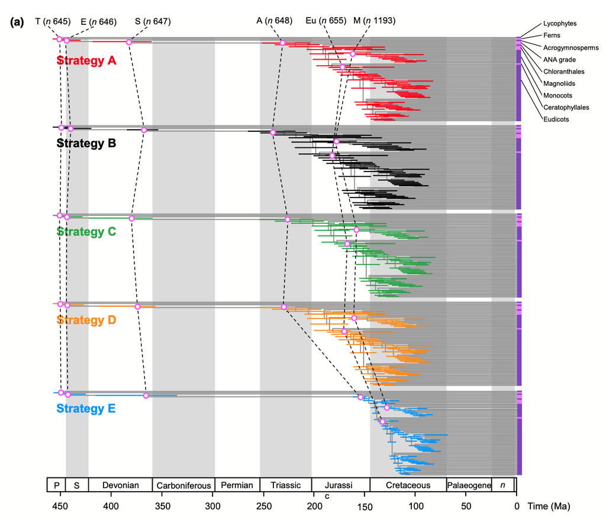

Effect of different calibrations on estimated node ages. Fig. 3 from Barba-Montoya et al. (2018)

## Strong effect of calibration choice

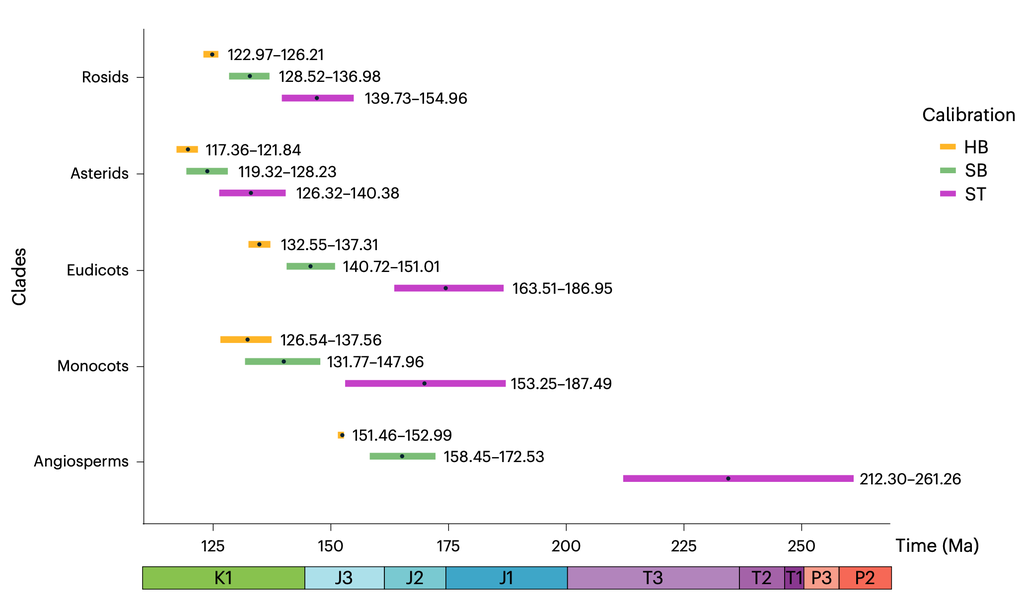

Effect of different calibrations on estimated node ages. Fig. 3 from Wu et al. (2026)

# Clock models

## Strict vs. relaxed clocks

- **Strict clock:** one rate $r$ for the whole tree. Simple, but real lineages vary (life history, generation time, mutation rate).
- **Relaxed clock:** each branch draws its own rate, e.g. from a **lognormal**:

$$r_i \sim \text{Lognormal}(\mu_r, \sigma_r),$$

with $\sigma_r$ measuring how **clock-like** the data are (Drummond et al. 2006).

- Uncorrelated (branch rates independent) vs. autocorrelated (parent→child) variants.
- Plants often violate a strict clock — herbs vs. trees differ in substitution rate.

## Relaxed clocks with Bayesian divergence-time estimation

Put it together in one hierarchical model, sampled by MCMC:

$$\underbrace{P(\text{data}\mid \tau, t, r)}_{\text{substitution + clock}}
\;\times\;
\underbrace{P(\tau, t)}_{\text{tree prior}}
\;\times\;
\underbrace{P(\text{calibrations})}_{\text{time priors}}.$$

- Output: a posterior distribution of **time-calibrated trees**.
- Every node age has a **95% HPD interval** for time and every branch has a **95% HPD interval** for its rate.

# Case study: Angiosperms

## 93 genera, five partitions, 52 fossils

- **Data:** a **93-genus subsample** (84 angiosperms + 9 outgroups) of the 644-genus data set of Barba-Montoya et al. (2018), with 75,030 aligned sites in **five partitions**: plastid and mitochondrial codon positions 1+2 and 3 (modelled separately), and nuclear rDNA.
- **Why subsample?** Cost per MCMC iteration grows with the number of nodes. We kept the fewest genera that preserve **all 52 calibrated nodes** and the major clades (22 have a genome): runs take a few hours instead of days.
- **Fixed topology**, Bayesian dating in **MCMCtree** (Yang 2007) with the **approximate likelihood** (Reis and Yang 2011).
- **Clock:** independent log-normal rates (a relaxed clock); **tree prior:** birth–death.
- **Calibrations:** 52 fossil constraints with **soft bounds** (Yang and Rannala 2006) — 41 minimum ages and 11 minimum-and-maximum ages.

| Partition | Sites |
| --- | --- |
| plastid, codon positions 1+2 | 41,021 |
| plastid, codon position 3 | 20,360 |
| mitochondrial, 1+2 | 5,690 |
| mitochondrial, 3 | 2,878 |
| nuclear rDNA | 5,081 |

## Where the calibrations are

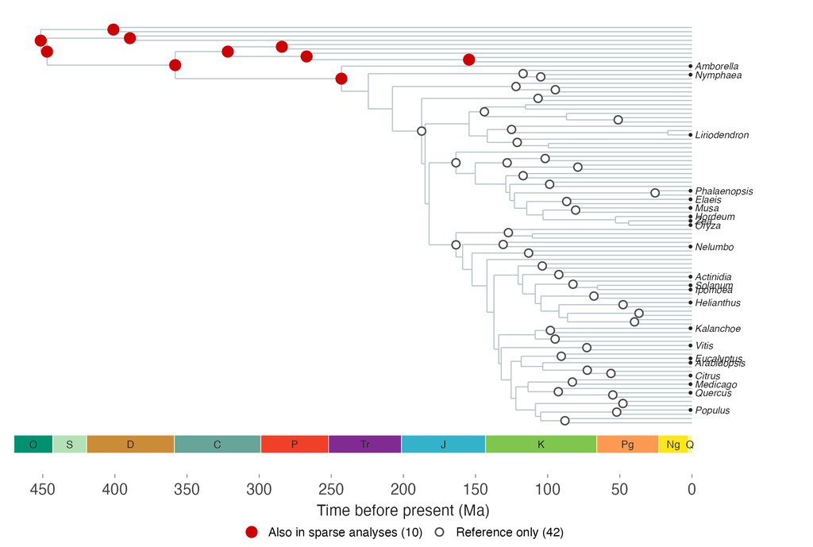

- **Red (10):** deep backbone — root, seed plants, gymnosperms, ferns, lycophytes — plus the **angiosperm crown** (126–247 Ma).
- **Open (42):** fossil calibrations inside the angiosperms (41 minimum ages and one minimum–maximum on the mesangiosperms), used only in the reference analysis.

## The reference timescale (analysis A)

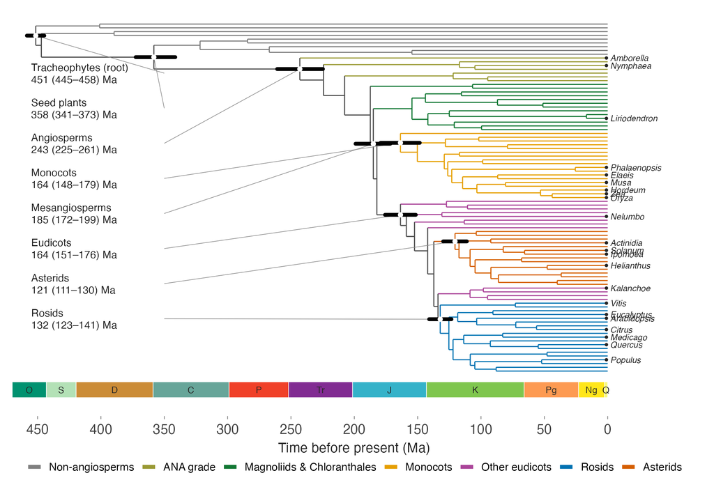

- Relaxed clock, **all 52 calibrations**: angiosperm crown **≈243 Ma** (95% HPD 225–261); major angiosperm clades have HPD widths of about 20–40 My.
- These are ages from the **93-genus subsample**; see the check below before quoting them.

## A comparison: how much do the calibrations and the clock matter?

Same alignment, topology, tree prior and approximate likelihood. **Only the calibrations and the clock change:**

|  | Clock | Calibrations |
| --- | --- | --- |
| **A** reference | relaxed (independent log-normal) | all 52 |
| **B** | relaxed | angiosperm crown + deep backbone only (10) |
| **C** | **strict** | angiosperm crown + deep backbone only (10) |

Can you make any predictions about how ages and rates will change with fewer calibrations throughout the tree?

## Answer 1: fewer fossils make the angiosperms *younger*

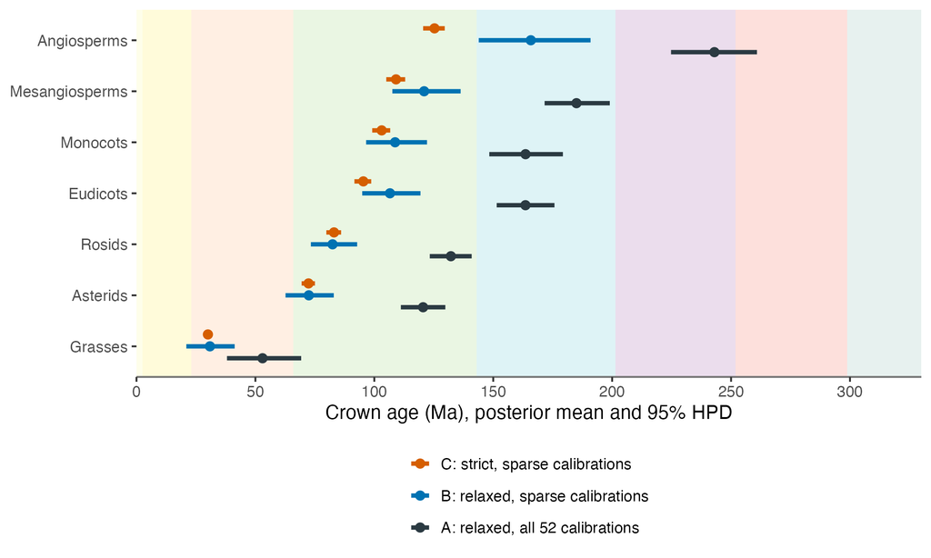

- **A → B** (drop the 42 angiosperm fossils): angiosperm crown **243 → 166 Ma**; every angiosperm clade moves **~30–40% younger**, and the crown interval is **wider** (HPD 36 → 47 My).
- **B → C** (strict clock): **younger still** (crown **125 Ma**) with a *tiny* interval (HPD 9 My).

## Answer 2: every node moves, not just the calibrated ones

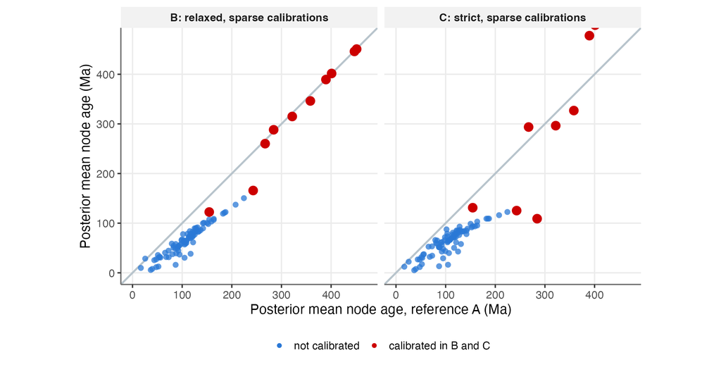

- **B vs A:** the calibrated backbone nodes (red, old) sit on the 1:1 line; the **uncalibrated angiosperm nodes** shift younger (median 0.61 × the reference age).
- **C vs A:** no calibrated node is safe — a **single rate** has to explain both slow gymnosperms/ferns and fast angiosperms.

## Strict clock: precise, but in conflict with the fossils

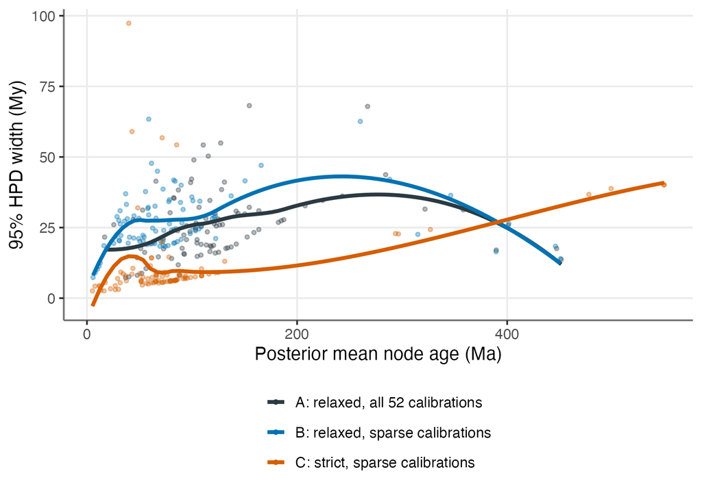

- **Median HPD width, all nodes:** A **25 My**, B **25 My**, C **7 My**. The strict clock looks like the *best-determined* analysis.
- But **6 of its 10 calibrated nodes** have a 95% HPD **entirely outside** the fossil bounds — e.g. the root at **550 Ma** vs. a 422–451 Ma constraint, and a gymnosperm node at **109 Ma** vs. 265–366 Ma.
- Under A and B: **0 of 10**.

## Why the ages move: rate and time trade off

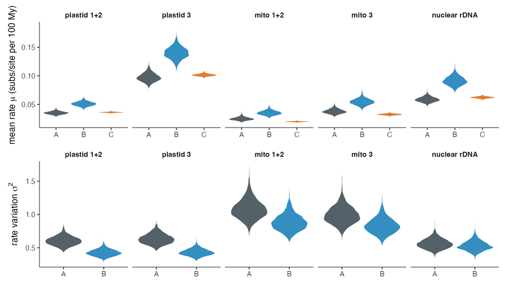

- **B has younger nodes and higher rates:** the mean rate rises by about **45%** in every partition (plastid 1+2: 0.035 → 0.051 subs/site per 100 My).
- **Third codon positions** evolve fastest (plastid 3: ≈ 0.10, about 3× codon positions 1+2), which is why we model them separately.
- The data fix only $r\times t$ (the **non-identifiability** slide): fewer fossils let $t$ shrink and $r$ grow to compensate.
- **Rate variation is large** ($\sigma^2\approx$ 0.4–1.1), so one global rate (C) cannot be right. Rate variation is lower in B than in A.

## Prior vs. posterior: where does the crown age come from?

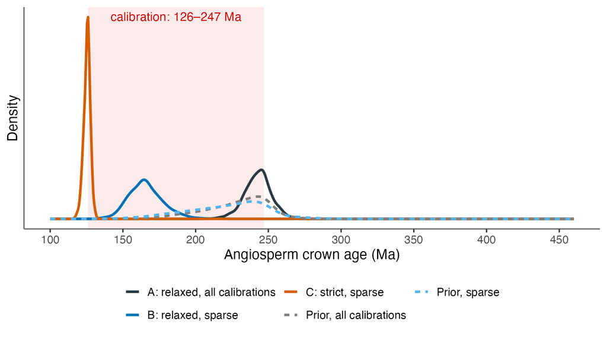

- **Prior only** (no sequence data, dashed): broad, **≈225–230 Ma** (95% 163–265 for the sparse set) — the birth–death prior plus calibrations on the other nodes.
- **A**’s posterior is close to its prior; **B**’s pulls **younger** (166 Ma), so the sequences themselves favour a younger crown when the interior fossils are absent. **C** collapses to a narrow spike at the 126 Ma lower bound.
- Always **compare posterior with the effective prior** — the prior is not just the calibration you typed in.

## Does the 93-genus subsample bias the ages?

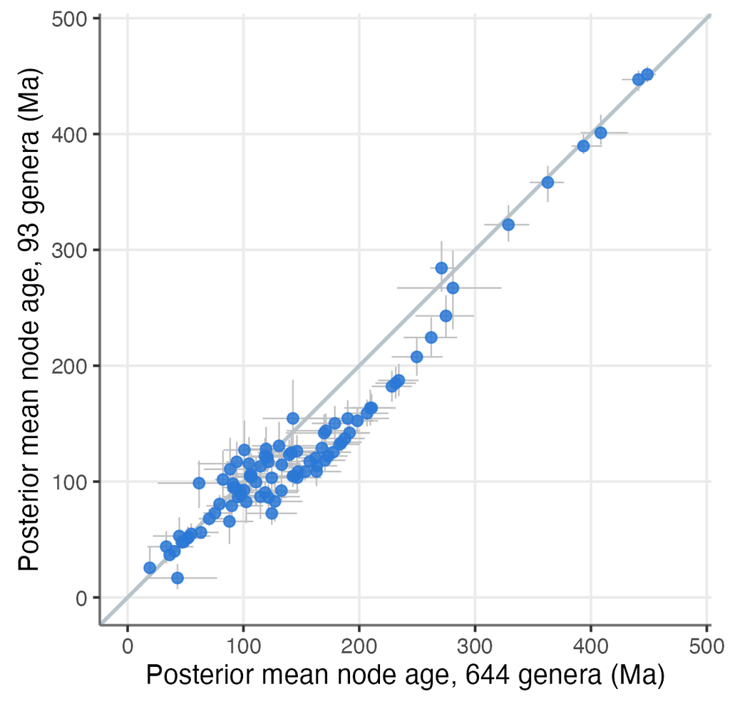

- **Deep backbone agrees** (root 449 vs. 451 Ma; gymnosperms 329 vs. 322 Ma).
- **Angiosperm nodes are younger in the subsample:** crown 275 → 243 Ma, eudicots 211 → 164 Ma (median ratio 0.89).
- The **effective priors agree** (crown ≈ 229 vs. 227 Ma; 644 vs. 93 genera), so the shift comes from the data, not the priors.
- **Not a clean test:** the 644-genus run used **three** partitions (no third codon positions) and its chains are partial (R-hat up to 1.16), so the gap mixes taxon sampling with partitioning.
- **Use the three-way comparison for what changes (A → B → C), not for absolute ages.**

# Key takeaways

## Summary

- The **bootstrap** resamples alignment columns to measure **sampling error**: clade support is the fraction of replicates containing the clade — not the probability it is true, and blind to model bias.
- Branch length = **rate × time**.
- **Least squares** turns distances into node heights (half the mean distance across each node) in substitution units; **one calibration** rescales them to absolute time under a strict clock.
- **Calibrations** (fossils, secondary, biogeographic) are needed to obtain absolute time estimates.
- Relaxed clocks can accommodate many calibrations and thus rate variation across the tree.
- Bayesian relaxed clock models yield a **posterior of chronograms**. The posterior can be used to calculate the **HPD** to evaluate uncertainty.

# References

Barba-Montoya, Jose, Mario Dos Reis, Harald Schneider, Philip CJ Donoghue, and Ziheng Yang. 2018. “Constraining Uncertainty in the Timescale of Angiosperm Evolution and the Veracity of a Cretaceous Terrestrial Revolution.” *New Phytologist* 218 (2): 819–34.

Drummond, Alexei J., Simon Y. W. Ho, Matthew J. Phillips, and Andrew Rambaut. 2006. “Relaxed Phylogenetics and Dating with Confidence.” *PLoS Biology* 4 (5): e88. https://doi.org/10.1371/journal.pbio.0040088.

Efron, B. 1979. “Bootstrap Methods: Another Look at the Jackknife.” *The Annals of Statistics* 7 (1): 1–26. https://doi.org/10.1214/aos/1176344552.

Felsenstein, Joseph. 1985. “Confidence Limits on Phylogenies: An Approach Using the Bootstrap.” *Evolution* 39 (4): 783–91. https://doi.org/10.1111/j.1558-5646.1985.tb00420.x.

Hillis, David M., and J. J. Bull. 1993. “An Empirical Test of Bootstrapping as a Method for Assessing Confidence in Phylogenetic Analysis.” *Systematic Biology* 42 (2): 182–92. https://doi.org/10.2307/2992540.

Hoang, Diep Thi, Olga Chernomor, Arndt von Haeseler, Bui Quang Minh, and Le Sy Vinh. 2018. “UFBoot2: Improving the Ultrafast Bootstrap Approximation.” *Molecular Biology and Evolution* 35 (2): 518–22. https://doi.org/10.1093/molbev/msx281.

Reis, Mario dos, and Ziheng Yang. 2011. “Approximate Likelihood Calculation on a Phylogeny for Bayesian Estimation of Divergence Times.” *Molecular Biology and Evolution* 28 (7): 2161–72. https://doi.org/10.1093/molbev/msr045.

Renner, Susanne S. 2005. “Relaxed Molecular Clocks for Dating Historical Plant Dispersal Events.” *Trends in Plant Science* 10 (11): 550–58.

Smith, Stephen A, and Michael J Donoghue. 2008. “Rates of Molecular Evolution Are Linked to Life History in Flowering Plants.” *Science* 322 (5898): 86–89.

To, Thu-Hien, Matthieu Jung, Samantha Lycett, and Olivier Gascuel. 2016. “Fast Dating Using Least-Squares Criteria and Algorithms.” *Systematic Biology* 65 (1): 82–97. https://doi.org/10.1093/sysbio/syv068.

Wu, Ruolin, Sandra Álvarez-Carretero, Yue Tong, Shan Wan, Harald Schneider, James Clark, Davide Pisani, Daniele Silvestro, and Philip CJ Donoghue. 2026. “Integrated Analysis of Fossils and Molecular Divergence Time Estimates a Latest Jurassic Origin of Angiosperms.” *Nature Plants* 12 (6): 1242–51.

Yang, Ziheng. 2007. “PAML 4: Phylogenetic Analysis by Maximum Likelihood.” *Molecular Biology and Evolution* 24 (8): 1586–91. https://doi.org/10.1093/molbev/msm088.

Yang, Ziheng, and Bruce Rannala. 2006. “Bayesian Estimation of Species Divergence Times Under a Molecular Clock Using Multiple Fossil Calibrations with Soft Bounds.” *Molecular Biology and Evolution* 23 (1): 212–26. https://doi.org/10.1093/molbev/msj024.